# Practica2

Miriam, Oriol, Ulises, Víctor

2026-01-12

## **Ejercicio 1.1**

**Descargar la página web de la URL indicada, y almacenarlo en un formato de R apto para ser tratado.El primer paso para realizar tareas de crawling y scraping es poder descargar los datos de la web. Para esto usaremos la capacidad de R y de sus librerías (httr y XML) para descargar webs y almacenarlas en variables que podamos convertir en un formato fácil de analizar (p.e. de HTML a XML).**

Cargamos e instalamos las librerías necesarias para hacer la práctica: HTTR, XML, ggplot2, gridExtra

Utilizando la librería HTTR hacemos un GET para descargarnos la página web “https://www.mediawiki.org/wiki/MediaWiki”. Después, mediante la librería XML obtenemos el xml de la web.

## **Ejercicio 1.2**

**Analizar el contenido de la web, buscando el título de la página (que en HTML se etiqueta como “title”). En las cabeceras web encontramos información como el título, los ficheros de estilo visual, y meta-información como el nombre del autor de la página, una descripción de esta, el tipo de codificación de esta, o palabras clave que indican qué tipo de información contiene la página. Una vez descargada la página, y convertida a un formato analizable (como XML), buscaremos los elementos de tipo title.**

Buscamos elemento tipo title mediante xpathSApply:

```
MediaWiki
```

## **Ejercicio 1.3**

**Analizar el contenido de la web, buscando todos los enlaces (que en HTML se etiquetan como “a”), buscando el texto del enlace, así como la URL.Vamos a extraer, usando las funciones de búsqueda XML, todos los enlaces que salen de esta página con tal de listarlos y poder descargarlas más tarde. Sabemos que estos son elementos de tipo “< a >”, que tienen el atributo “href” para indicar la URL del enlace. Del enlace nos quedaremos con la URL de destino y con el valor del enlace (texto del enlace).**

Realizamos el análisis, obtenemos todos los enlaces y el texto:

|  | Enlace | Texto |
| --- | --- | --- |
| 1 | #bodyContent | Jump to content |
| 2 | /wiki/MediaWiki | Main page |
| 3 | /wiki/Download | Get MediaWiki |
| 4 | /wiki/Special:MyLanguage/Category:Extensions | Get extensions |
| 5 | https://techblog.wikimedia.org/ | Tech blog |
| 6 | /wiki/Special:MyLanguage/How_to_contribute | Contribute |
| 7 | /wiki/Special:MyLanguage/Help:Contents | User help |
| 8 | /wiki/Special:MyLanguage/Manual:FAQ | FAQ |
| 9 | /wiki/Special:MyLanguage/Manual:Contents | Technical manual |
| 10 | /wiki/Project:Support_desk | Support desk |

[output cut: 181 more lines]

## **Ejercicio 1.4**

**Generar una tabla con cada enlace encontrado, indicando el texto que acompaña el enlace, y el número de veces que aparece un enlace con ese mismo objetivo. En este paso nos interesa reunir los datos obtenidos en el anterior paso. Tendremos que comprobar, para cada enlace, cuantas veces aparece.**

|  | Enlace | Texto | Visto |
| --- | --- | --- | --- |
| 1 | # |  | 7 |
| 2 | # | Add topic | 1 |
| 3 | # | English | 1 |
| 4 | #bodyContent | Jump to content | 1 |
| 5 | //commons.wikimedia.org/wiki/Special:UploadWizard | Upload file | 1 |
| 6 | //www.mediawiki.org/w/index.php?title=MediaWiki&amp;mobileaction=toggle_view_mobile | Mobile view | 1 |
| 7 | /w/index.php?title=MediaWiki&amp;action=edit | View source | 2 |
| 8 | /w/index.php?title=MediaWiki&amp;action=history | View history | 2 |
| 9 | /w/index.php?title=MediaWiki&amp;action=info | Page information | 1 |
| 10 | /w/index.php?title=MediaWiki&amp;oldid=6287429 | Permanent link | 1 |

[output cut: 170 more lines]

## **Ejercicio 1.5**

**Para cada enlace, seguirlo e indicar si está activo (podemos usar el código de status HTTP al hacer una petición a esa URL).**

Primero normalizamos los enlaces, creamos una nueva columna con las URLs normalizadas que utilizaremos posteriormente para obtener los status. Mantenemos la columna de las URLs sin normalizar para no alterar la columna Visto.

|  | Enlace | Enlace_Normalizado | Texto | Visto |
| --- | --- | --- | --- | --- |
| 1 | # | https://www.mediawiki.org/wiki/MediaWiki# |  | 7 |
| 2 | # | https://www.mediawiki.org/wiki/MediaWiki# | Add topic | 1 |
| 3 | # | https://www.mediawiki.org/wiki/MediaWiki# | English | 1 |
| 4 | #bodyContent | https://www.mediawiki.org/wiki/MediaWiki#bodyContent | Jump to content | 1 |
| 5 | //commons.wikimedia.org/wiki/Special:UploadWizard | https://commons.wikimedia.org/wiki/Special:UploadWizard | Upload file | 1 |
| 6 | //www.mediawiki.org/w/index.php?title=MediaWiki&amp;mobileaction=toggle_view_mobile | https://www.mediawiki.org/w/index.php?title=MediaWiki&amp;mobileaction=toggle_view_mobile | Mobile view | 1 |
| 7 | /w/index.php?title=MediaWiki&amp;action=edit | https://www.mediawiki.org/w/index.php?title=MediaWiki&amp;action=edit | View source | 2 |
| 8 | /w/index.php?title=MediaWiki&amp;action=history | https://www.mediawiki.org/w/index.php?title=MediaWiki&amp;action=history | View history | 2 |
| 9 | /w/index.php?title=MediaWiki&amp;action=info | https://www.mediawiki.org/w/index.php?title=MediaWiki&amp;action=info | Page information | 1 |
| 10 | /w/index.php?title=MediaWiki&amp;oldid=6287429 | https://www.mediawiki.org/w/index.php?title=MediaWiki&amp;oldid=6287429 | Permanent link | 1 |

[output cut: 170 more lines]

Una vez tenemos las URLs normalizadas,podemos obtener los status:

Nota: para no ser baneados establecemos un sleep(0.5)

|  | Enlace | Enlace_Normalizado | Texto | Visto | status |
| --- | --- | --- | --- | --- | --- |
| 1 | # | https://www.mediawiki.org/wiki/MediaWiki# |  | 7 | 200 |
| 2 | # | https://www.mediawiki.org/wiki/MediaWiki# | Add topic | 1 | 200 |
| 3 | # | https://www.mediawiki.org/wiki/MediaWiki# | English | 1 | 200 |
| 4 | #bodyContent | https://www.mediawiki.org/wiki/MediaWiki#bodyContent | Jump to content | 1 | 200 |
| 5 | //commons.wikimedia.org/wiki/Special:UploadWizard | https://commons.wikimedia.org/wiki/Special:UploadWizard | Upload file | 1 | 200 |
| 6 | //www.mediawiki.org/w/index.php?title=MediaWiki&amp;mobileaction=toggle_view_mobile | https://www.mediawiki.org/w/index.php?title=MediaWiki&amp;mobileaction=toggle_view_mobile | Mobile view | 1 | 200 |
| 7 | /w/index.php?title=MediaWiki&amp;action=edit | https://www.mediawiki.org/w/index.php?title=MediaWiki&amp;action=edit | View source | 2 | 200 |
| 8 | /w/index.php?title=MediaWiki&amp;action=history | https://www.mediawiki.org/w/index.php?title=MediaWiki&amp;action=history | View history | 2 | 200 |
| 9 | /w/index.php?title=MediaWiki&amp;action=info | https://www.mediawiki.org/w/index.php?title=MediaWiki&amp;action=info | Page information | 1 | 200 |
| 10 | /w/index.php?title=MediaWiki&amp;oldid=6287429 | https://www.mediawiki.org/w/index.php?title=MediaWiki&amp;oldid=6287429 | Permanent link | 1 | 200 |

[output cut: 170 more lines]

# Pregunta 2

## **Ejercicio 2.1**

**Un histograma con la frecuencia de aparición de los enlaces, pero separado por URLs absolutas (con “http…”) y URLs relativas.**

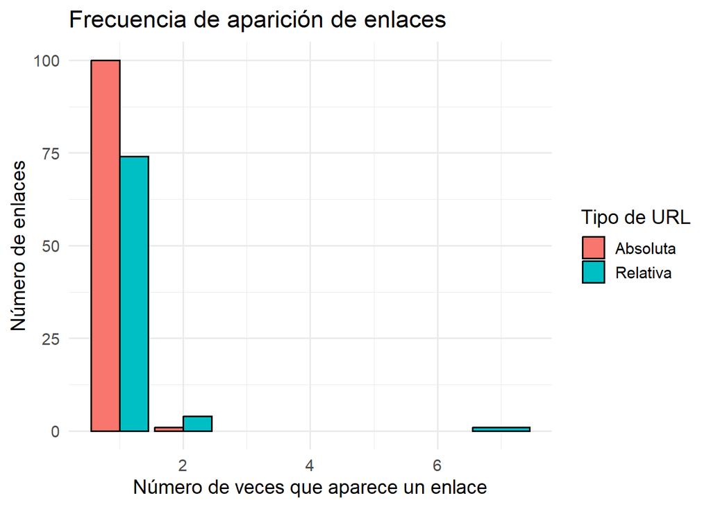

## **Ejercicio 2.2**

**Un gráfico de barras indicando la suma de enlaces que apuntan a otros dominios o servicios (distinto a https://www.mediawiki.org en el caso de ejemplo) vs. la suma de los otros enlaces. Aquí queremos distinguir enlaces que apuntan a mediawiki versus el resto. Sabemos que las URLs relativas ya apuntan dentro, por lo tanto hay que analizar las URLs absolutas y comprobar que apunten a https://www.mediawiki.org.**

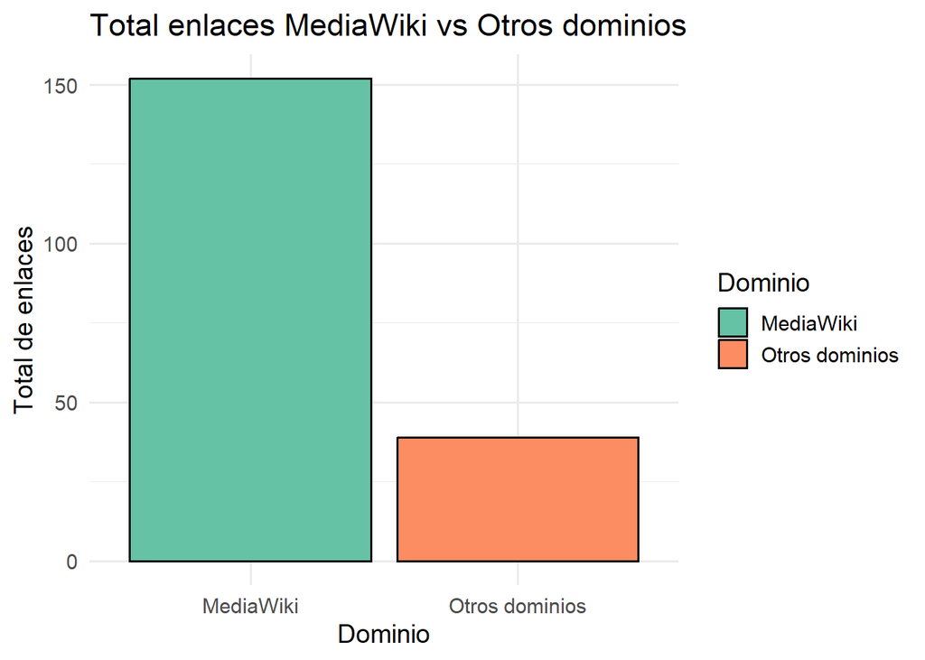

## **Ejercicio 2.3**

**Un gráfico de tarta (pie chart) indicando los porcentajes de Status de nuestro análisis. Por ejemplo, si hay 6 enlaces con status “200” y 4 enlaces con status “404”, la tarta mostrará un 60% con la etiqueta “200” y un 40% con la etiqueta “404”. Este gráfico lo uniremos a los anteriores. El objetivo final es obtener una imagen que recopile los gráficos generados.**

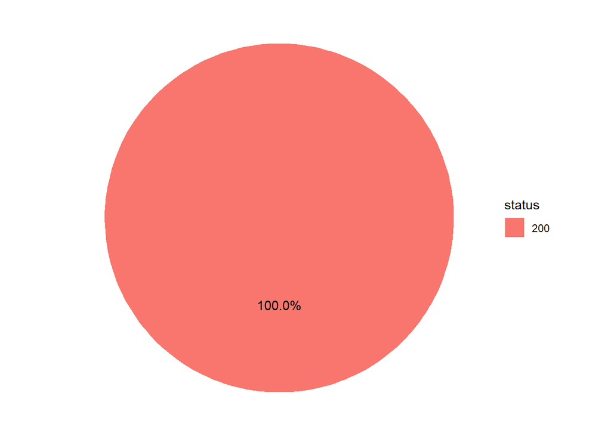